# tidymodels_example

## Predictive modeling case study for tidymodels package

This case study brings all the different components from the getstarted tutorials together. Hopefully this will be useful to walk through and then reference in the future when I'm building my own models.

```r
hotels <-
  read_csv('https://tidymodels.org/start/case-study/hotels.csv') %>%
  mutate_if(is.character, as.factor)
glimpse(hotels)
```

```
## Rows: 50,000
## Columns: 23
## $ hotel                          <fct> City_Hotel, City_Hotel, Resort_Hotel...
## $ lead_time                      <dbl> 217, 2, 95, 143, 136, 67, 47, 56, 80...
## $ stays_in_weekend_nights        <dbl> 1, 0, 2, 2, 1, 2, 0, 0, 0, 2, 1, 0, ...
## $ stays_in_week_nights           <dbl> 3, 1, 5, 6, 4, 2, 2, 3, 4, 2, 2, 1, ...
## $ adults                         <dbl> 2, 2, 2, 2, 2, 2, 2, 0, 2, 2, 2, 1, ...
## $ children                       <fct> none, none, none, none, none, none, ...
## $ meal                           <fct> BB, BB, BB, HB, HB, SC, BB, BB, BB, ...
## $ country                        <fct> DEU, PRT, GBR, ROU, PRT, GBR, ESP, E...
## $ market_segment                 <fct> Offline_TA/TO, Direct, Online_TA, On...
## $ distribution_channel           <fct> TA/TO, Direct, TA/TO, TA/TO, Direct,...
## $ is_repeated_guest              <dbl> 0, 0, 0, 0, 0, 0, 0, 0, 0, 0, 0, 0, ...
## $ previous_cancellations         <dbl> 0, 0, 0, 0, 0, 0, 0, 0, 0, 0, 0, 0, ...
## $ previous_bookings_not_canceled <dbl> 0, 0, 0, 0, 0, 0, 0, 0, 0, 0, 0, 0, ...
## $ reserved_room_type             <fct> A, D, A, A, F, A, C, B, D, A, A, D, ...
## $ assigned_room_type             <fct> A, K, A, A, F, A, C, A, D, A, D, D, ...
## $ booking_changes                <dbl> 0, 0, 2, 0, 0, 0, 0, 0, 0, 0, 0, 0, ...
## $ deposit_type                   <fct> No_Deposit, No_Deposit, No_Deposit, ...
## $ days_in_waiting_list           <dbl> 0, 0, 0, 0, 0, 0, 0, 0, 0, 0, 0, 0, ...
## $ customer_type                  <fct> Transient-Party, Transient, Transien...
## $ average_daily_rate             <dbl> 80.75, 170.00, 8.00, 81.00, 157.60, ...
## $ required_car_parking_spaces    <fct> none, none, none, none, none, none, ...
## $ total_of_special_requests      <dbl> 1, 3, 2, 1, 4, 1, 1, 1, 1, 1, 0, 1, ...
## $ arrival_date                   <date> 2016-09-01, 2017-08-25, 2016-11-19,...
```

We are building a model to predict when hotel stays included chilren.

```r
hotels %>% count(children) %>%
  mutate(prop = n/sum(n))
```

```
## # A tibble: 2 x 3
##   children     n   prop
##   <fct>    <int>  <dbl>
## 1 children  4038 0.0808
## 2 none     45962 0.919
```

```r
#note that this is imbalanced. Rather than upsampling or down sampling we are going to just go ahead as is.

set.seed(123)
splits <- initial_split(hotels, strata = children)
hotel_other <-  training(splits)
hotel_test <- testing(splits)

#rather than doing folded CV, we are going to use a single validation set. Banking on the idea that the single validation set is large enough to give us a good estimate of actual model performance.
val_set <- validation_split(hotel_other,
                            strata = children,
                            prop = 0.80)
val_set
```

```
## # Validation Set Split (0.8/0.2)  using stratification
## # A tibble: 1 x 2
##   splits             id
##   <list>             <chr>
## 1 <split [30K/7.5K]> validation
```

# First model: penalized logistic regression

We want our model to do feature selection during training. We are going to use the glmnet package for this, which uses penalized maximum likelihood to fit model. This is a package for implementing lasso or ridge regression. Interestingly can set a mixture between the two in the logistic_reg function, with mixture =1 being pure lasso.

```r
lr_mod <- logistic_reg(penalty = tune(),mixture=1) %>%
  set_engine("glmnet")

holidays <- c("AllSouls", "AshWednesday", "ChristmasEve", "Easter",
              "ChristmasDay", "GoodFriday", "NewYearsDay", "PalmSunday")

lr_recipe <-
  recipe(children ~ ., data = hotel_other) %>%
  step_date(arrival_date) %>%
  step_holiday(arrival_date, holidays = holidays) %>%
  step_rm(arrival_date) %>%
  step_dummy(all_nominal(), -all_outcomes()) %>%
  step_zv(all_predictors()) %>%
  step_normalize(all_predictors())

lr_workflow <-  workflow() %>%
  add_model(lr_mod)%>%
  add_recipe(lr_recipe)

lr_reg_grid <- tibble(penalty = 10^seq(-4, -1, length.out = 30))
```

```r
lr_res <-
  lr_workflow %>%
  tune_grid(val_set,
            grid = lr_reg_grid,
            control = control_grid(save_pred = TRUE),
            metrics = metric_set(roc_auc))
```

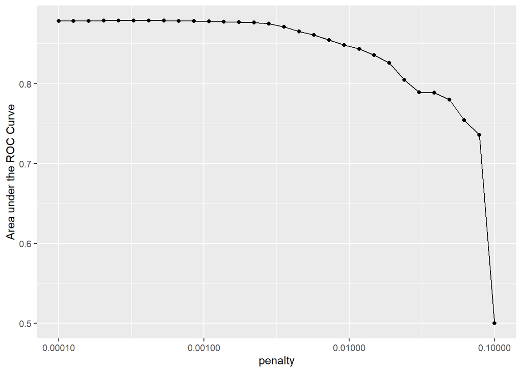

```r
lr_plot <-
  lr_res %>%
  collect_metrics() %>%
  ggplot(aes(x = penalty, y = mean)) +
  geom_point() +
  geom_line() +
  ylab("Area under the ROC Curve") +
  scale_x_log10(labels = scales::label_number())

lr_plot
```

Here we see that the inflection point is around .00137, and so we are going to choose that value for out tuned hyperparameter as it will minimize the number of predictors without losing accuracy.

```r
lr_best <-
  lr_res %>%
  collect_metrics() %>%
  arrange(penalty) %>%
  slice(12)#this is hard coded in, which isn't ideal
lr_best
```

```
## # A tibble: 1 x 7
##   penalty .metric .estimator  mean     n std_err .config
##     <dbl> <chr>   <chr>      <dbl> <int>   <dbl> <chr>
## 1 0.00137 roc_auc binary     0.878     1      NA Preprocessor1_Model12
```

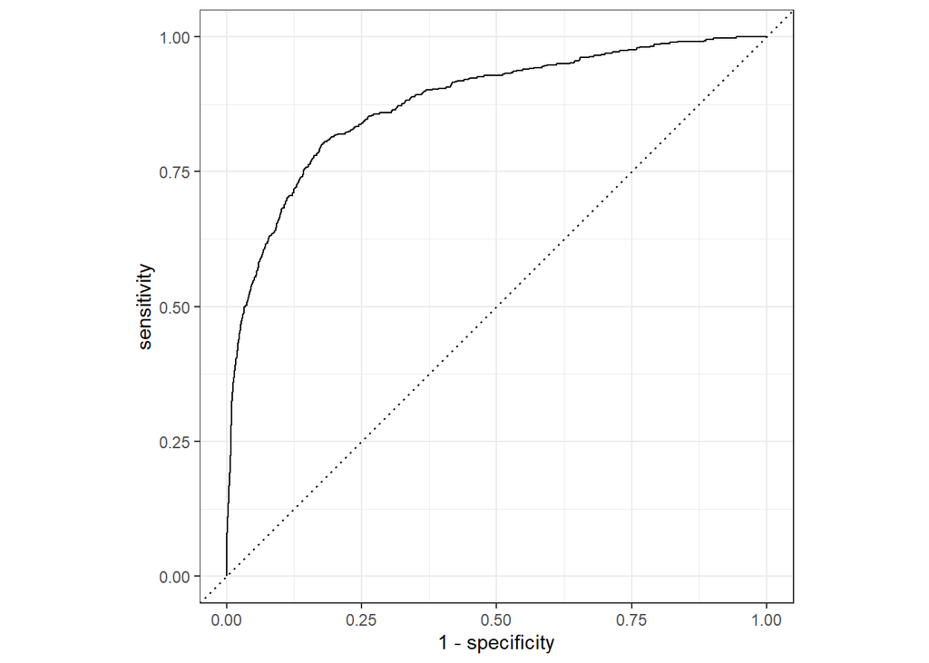

```r
lr_auc <-
  lr_res %>%
  collect_predictions(parameters = lr_best) %>%
  roc_curve(children, .pred_children) %>%
  mutate(model = "Logistic Regression")

autoplot(lr_auc)
```

# Second model: tree-based ensemble

aside: the ranger package can be used to compute individual random forest models in parallel even if you are using a single validation set. **do not do this in most contexts, it's usually better to let the tune package handle this if you are using any other resampling method like cross validation**

```r
cores <- parallel::detectCores()
cores
```

```
## [1] 4
```

```r
rf_mod <- rand_forest(mtry = tune(),min_n = tune(), trees = 500)%>% #n trees was 1000 before
  set_engine("ranger", num.threads = cores) %>%
  set_mode("classification")

rf_recipe <-  recipe(children ~., data = hotel_other) %>%
  step_date(arrival_date) %>%
  step_holiday(arrival_date) %>%
  step_rm(arrival_date)

rf_workflow <-
  workflow() %>%
  add_model(rf_mod) %>%
  add_recipe(rf_recipe)
```

It takes a fairly long time to do model tuning on this, because you have to run N iterations each of which takes my computer a while. I ended up reducing the number of tuning points and number of trees per forest to make it run a little faster and so I won't get as good of results as the tutorial probably.

```r
set.seed(345)
rf_res <-
  rf_workflow %>%
  tune_grid(val_set,
            grid =5, #25,
            control = control_grid(save_pred = TRUE),
            metrics = metric_set(roc_auc))
```

```
## i Creating pre-processing data to finalize unknown parameter: mtry
```

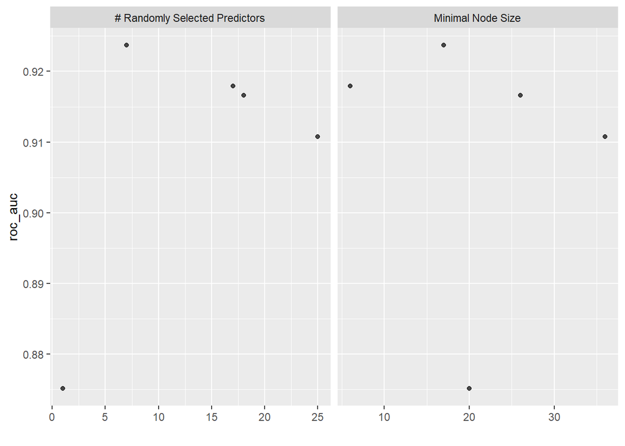

```r
autoplot(rf_res)
```

```r
rf_res %>%
  show_best(metric = "roc_auc")
```

```
## # A tibble: 5 x 8
##    mtry min_n .metric .estimator  mean     n std_err .config
##   <int> <int> <chr>   <chr>      <dbl> <int>   <dbl> <chr>
## 1     7    17 roc_auc binary     0.924     1      NA Preprocessor1_Model4
## 2    17     6 roc_auc binary     0.918     1      NA Preprocessor1_Model1
## 3    18    26 roc_auc binary     0.917     1      NA Preprocessor1_Model5
## 4    25    36 roc_auc binary     0.911     1      NA Preprocessor1_Model3
## 5     1    20 roc_auc binary     0.875     1      NA Preprocessor1_Model2
```

```r
rf_best <-
  rf_res %>%
  select_best(metric = "roc_auc")

rf_res %>%
  collect_predictions()
```

```
## # A tibble: 37,495 x 8
##    id        .pred_children .pred_none  .row  mtry min_n children .config
##    <chr>              <dbl>      <dbl> <int> <int> <int> <fct>    <chr>
##  1 validati~       0.042         0.958    14    17     6 none     Preprocessor1~
##  2 validati~       0             1        17    17     6 none     Preprocessor1~
##  3 validati~       0.0321        0.968    18    17     6 none     Preprocessor1~
##  4 validati~       0.0236        0.976    24    17     6 none     Preprocessor1~
##  5 validati~       0.118         0.882    26    17     6 none     Preprocessor1~
##  6 validati~       0             1        31    17     6 none     Preprocessor1~
##  7 validati~       0.000333      1.00     40    17     6 none     Preprocessor1~
##  8 validati~       0.151         0.849    48    17     6 none     Preprocessor1~
##  9 validati~       0.00967       0.990    53    17     6 none     Preprocessor1~
## 10 validati~       0.0894        0.911    55    17     6 none     Preprocessor1~
## # ... with 37,485 more rows
```

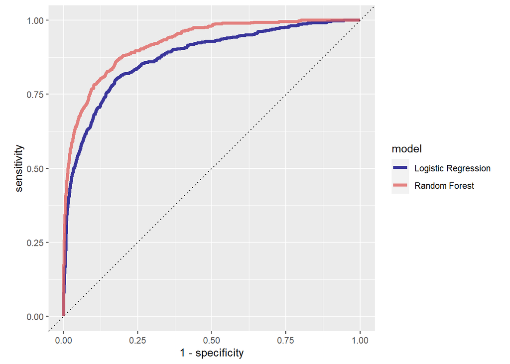

```r
rf_auc <-
  rf_res %>%
  collect_predictions(parameters = rf_best) %>%
  roc_curve(children, .pred_children) %>%
  mutate(model = "Random Forest")

bind_rows(rf_auc, lr_auc) %>%
  ggplot(aes(x = 1 - specificity, y = sensitivity, col = model)) +
  geom_path(lwd = 1.5, alpha = 0.8) +
  geom_abline(lty = 3) +
  coord_equal() +
  scale_color_viridis_d(option = "plasma", end = .6)
```

# The last model

```r
last_rf_mod <-
  rand_forest(mtry = 8, min_n = 7, trees = 1000) %>% #note the hardcoded params, also probably not ideal
  set_engine("ranger", num.threads = cores, importance = "impurity") %>%
  set_mode("classification")

# the last workflow
last_rf_workflow <-
  rf_workflow %>%
  update_model(last_rf_mod)

# the last fit
set.seed(345)
last_rf_fit <-
  last_rf_workflow %>%
  last_fit(splits)

last_rf_fit %>%
  collect_metrics()
```

```
## # A tibble: 2 x 4
##   .metric  .estimator .estimate .config
##   <chr>    <chr>          <dbl> <chr>
## 1 accuracy binary         0.947 Preprocessor1_Model1
## 2 roc_auc  binary         0.922 Preprocessor1_Model1
```

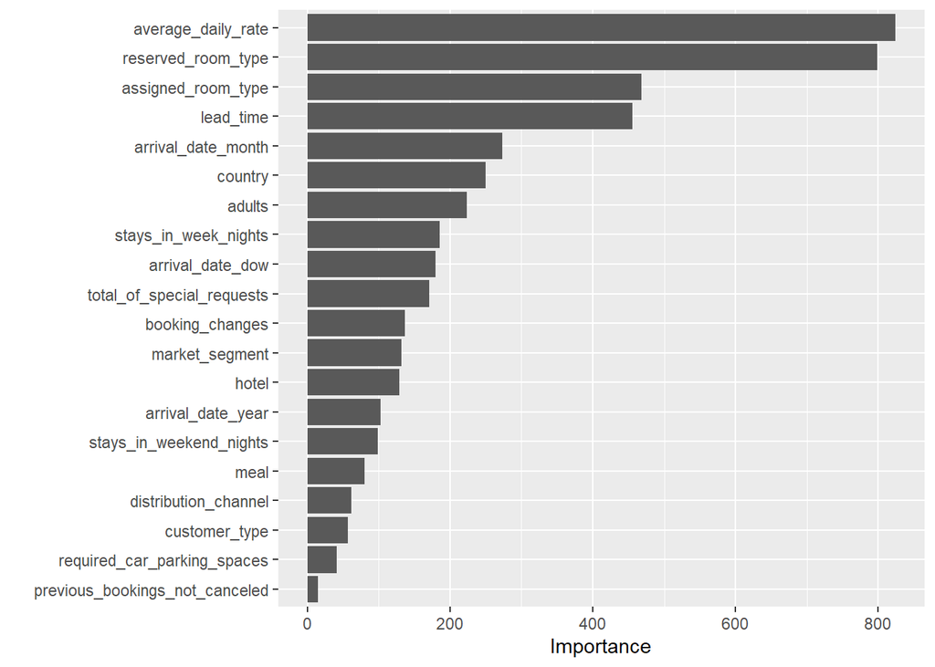

```r
last_rf_fit %>%
  pluck(".workflow", 1) %>%   #new thing here, plucking out the first workflow
  pull_workflow_fit() %>%
  vip(num_features = 20)
```

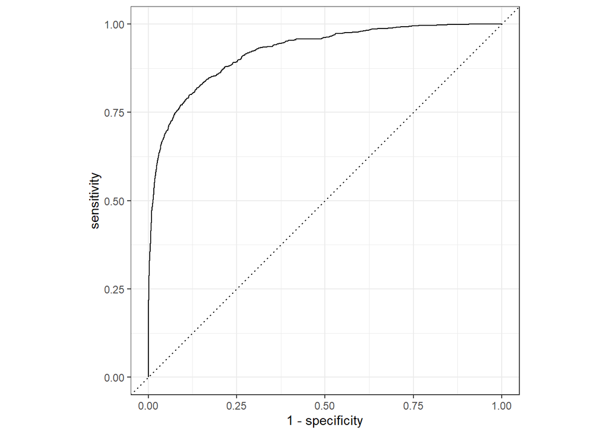

```r
last_rf_fit %>%
  collect_predictions() %>%
  roc_curve(children, .pred_children) %>%
  autoplot()
```